# Simulate Multi-State

analyze.eng@gmail.com

2024-06-20

# Context

I am interested in the idea that we can find biomarkers of a particular type by studying the joint (OS, PFS) process. A technical innovation is to consider the multi-state survival process of a particular topology.

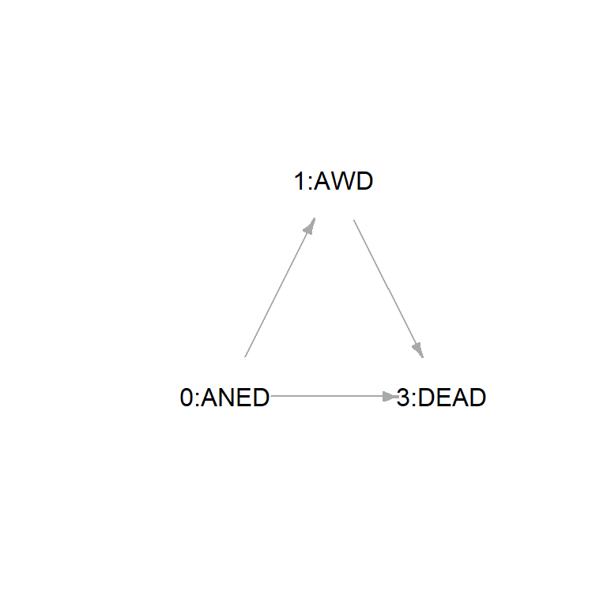

My plan is to generate data following `coxph(OS~b1*X)` and `coxph(PFS~b2*X)` and then to estimate the component hazards. I think that we will see a peculiar behavior as a function of covariates `(b1, b2)`.

Some questions about the censoring process are also relevant. Consider the independent censoring time that may follow `coxph(CENS~b3*X)` and the implications for the component hazards.

Analysis will follow https://cran.r-project.org/web/packages/survival/vignettes/compete.pdf

# TCGA Data Analysis

Data from TCGA-OV is available to show that this data structure exists in reality.

## Load Data

We are after the general `Surv(tstart,tstop,event)` data structure where `levels(event) = c("ANED","DEATH","PROGRESSION")`.

```r
## Each row is a person
x<-read.table(
            file = "Data/data_clinical_patient.txt",
            sep="\t",
            skip=4,
            row.names=1,
            header=TRUE)

## Convert to clear variables
dat1<-x[,c("OS_STATUS","OS_MONTHS","PFS_STATUS","PFS_MONTHS")]
dat1$time1<-dat1$OS_MONTHS
dat1$event1<-dat1$OS_STATUS=="1:DECEASED"
dat1$time2<-dat1$PFS_MONTHS
dat1$event2<-dat1$PFS_STATUS=="1:PROGRESSION"

## Drop bad records
dat1<-dat1[which(!is.na(dat1$time1)),]

## Construct the gap time
dat1$gaptime<-dat1$time1-dat1$time2
dat1$id<-rownames(dat1)

## Logic
## 1. if there is a gap time, then (0,time2,event="PROG")
##       and we need (time2,time1,event=event1)
## 2. if not then
##       we have just (0,time1,event=event1)
gate<-interaction(ifelse(dat1$gaptime>0,"gap","nogap"),
                  ifelse(dat1$event1,"died","alive"))
table(gate,useNA="a")
```

```
## gate
##   gap.alive nogap.alive    gap.died  nogap.died        <NA>
##          97         133         258          83           0
```

## Examine the OS and PFS time structure

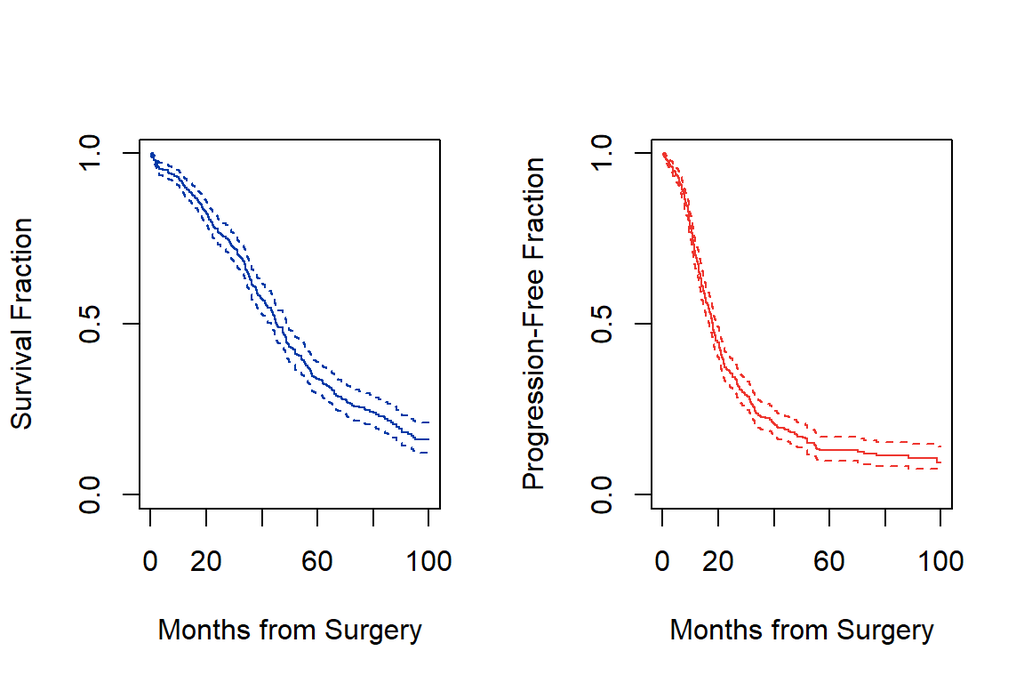

```r
km1<-survfit(Surv(time1,event1)~1,dat1)
km2<-survfit(Surv(time2,event2)~1,dat1)
mh1<-muhaz(dat1$time1,dat1$event1)
mh2<-muhaz(dat1$time2,dat1$event2)
ss1<-sshzd(Surv(time1,event1)~time1,data=dat1)
ss2<-sshzd(Surv(time2,event2)~time2,data=dat1)
tt<-seq(from=0,to=100,length=500)

xlim<-c(0,100)

par(mfrow=c(1,2))

## KM Plots
plot(km1,axes=FALSE,xlim=xlim,
     xlab="Months from Surgery",
     ylab="Survival Fraction")
  axis(1);axis(2,at=(0:2)/2);box()
plot(km2,axes=FALSE,xlim=xlim, col=2,
     xlab="Months from Surgery",
     ylab="Progression-Free Fraction")
  axis(1);axis(2,at=(0:2)/2);box()
```

```r
## Muhaz plots are not worth showing
#plot(mh1,ylab="Hazard of Death",xlim=xlim)
#plot(mh2,ylab="Hazard of Death or Progression",xlim=xlim)
```

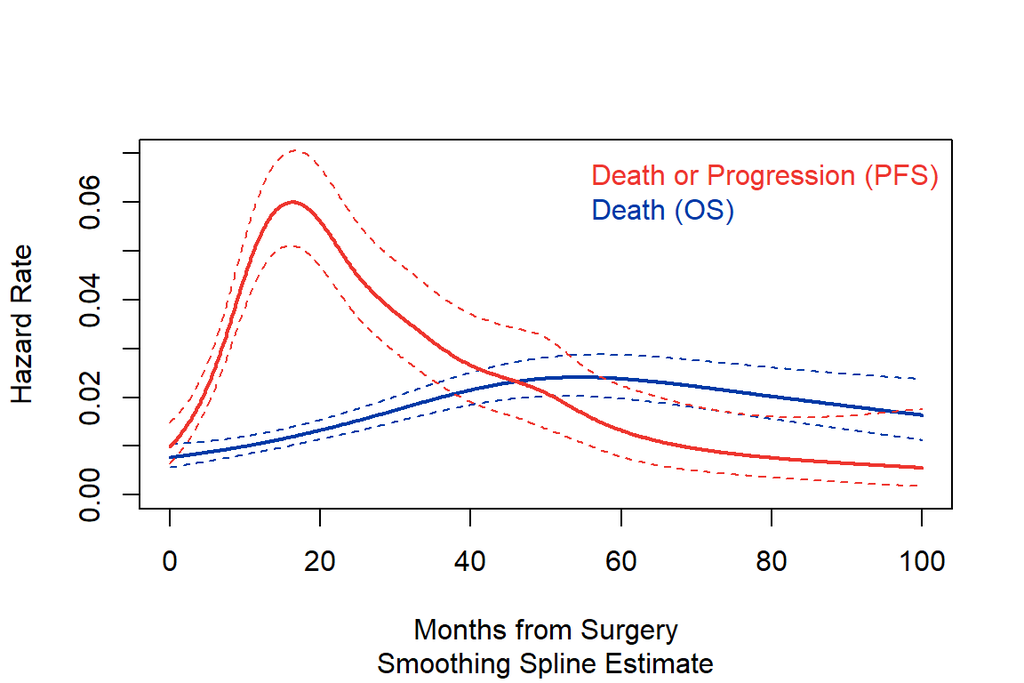

```r
## SS plots
h1<-hzdrate.sshzd(ss1,x=data.frame(time1=tt),se=TRUE)
h1<-h1$fit*exp(cbind(0,-h1$se.fit,h1$se.fit)*1.96)
h2<-hzdrate.sshzd(ss2,x=data.frame(time2=tt),se=TRUE)
h2<-h2$fit*exp(cbind(0,-h2$se.fit,h2$se.fit)*1.96)

matplot(tt,cbind(h1,h2),type="l",
        ylim=c(0,.07),lty=c(1,2,2),
        lwd=c(2,1,1),col=c(1,1,1,2,2,2),
        xlab="Months from Surgery",
        ylab="Hazard Rate",
        sub="Smoothing Spline Estimate")
legend("topright",text.col=2:1,
       legend=c("Death or Progression (PFS)","Death (OS)"),bty="n")
```

Discuss limitations. Hard to attribute hazard to one event or the other. Why is Death hazard higher than the combination hazard after 45 months? Unintuitive: PFS-related events have taken many people out of consideration. So people who die after progression aren’t considered. The difference might imply higher death after progression rates.

## Build Event Process Data structure

We can now start constructing the event-process data structure

```r
dat2<-split(dat1,f=gate)

## Paste together the (tstart,tend,event)
## Data structure using rules from above.
dat3<-
rbind(
  data.frame(tstart=0,
             tend=dat2[["nogap.alive"]][,c("time1")],
             event="cens",
             last="(s0)",
             id=dat2[["nogap.alive"]][,"id"]),
  data.frame(tstart=0,
             tend=dat2[["nogap.died"]][,"time1"],
             event="died",
             last="(s0)",
             id=dat2[["nogap.died"]][,"id"]),

  data.frame(tstart=0,
             tend=dat2[["gap.died"]][,"time2"],
             event="prog",
             last="(s0)",
             id=dat2[["gap.died"]][,"id"]),
  data.frame(tstart=dat2[["gap.died"]][,"time2"],
             tend=dat2[["gap.died"]][,"time1"],
             event="died",
             last="prog",
             id=dat2[["gap.died"]][,"id"]),

  data.frame(tstart=0,
             tend=dat2[["gap.alive"]][,"time2"],
             event="prog",
             last="(s0)",
             id=dat2[["gap.alive"]][,"id"]),
  data.frame(tstart=dat2[["gap.alive"]][,"time2"],
             tend=dat2[["gap.alive"]][,"time1"],
             event="cens",
             last="prog",
             id=dat2[["gap.alive"]][,"id"])
)
dat3$event<-factor(dat3$event,c("cens","prog","died"))
```

## Look at multistate data

This data structure is amenable to multi-state regression analysis. Here are some of the usual operations.

```r
library(survival)
mfit1<-survfit(Surv(tstart, tend, event) ~ 1, data=dat3, id=id)
print(mfit1,digits=3,rmean=180)
```

```
## Call: survfit(formula = Surv(tstart, tend, event) ~ 1, data = dat3,
##     id = id)
##
##        n nevent rmean*
## (s0) 926      0   30.6
## prog 926    355   28.2
## died 926    341  121.3
##    *restricted mean time in state (max time = 180 )
```

```r
mfit1$transitions
```

```
##       to
## from   prog died (censored)
##   (s0)  355   83        133
##   prog    0  258         97
##   died    0    0          0
```

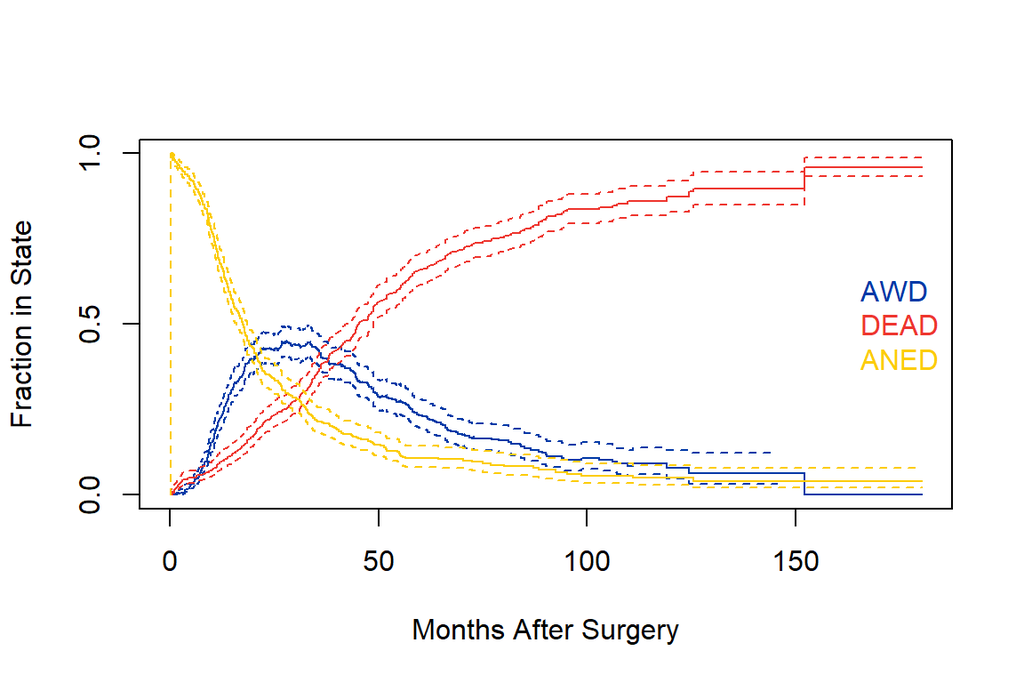

```r
plot(mfit1[,"prog"],xlab="Months After Surgery",
     ylab="Fraction in State",col=1,ylim=c(0,1),
     axes=FALSE)
box();axis(1);axis(2,at=(0:2)/2)
lines(mfit1[,"died"],col=2)
lines(mfit1[,"(s0)"],col=3)
legend("right",text.col=1:3,
       legend=c("AWD","DEAD","ANED"),bty="n")
```

Okay this is a nice way to look at the data.

## Consider hazards

```r
## Remember Chong Gu hardcoded a weird Surv(futime,status,start=0)
ssA<-sshzd(Surv(tend,event=="prog",start=tstart) ~ tend, data=dat3,
           subset=dat3$last=="(s0)")
ssB<-sshzd(Surv(tend,event=="died",start=tstart) ~ tend, data=dat3,
           subset=dat3$last=="prog")
ssC<-sshzd(Surv(tend,event=="died",start=tstart) ~ tend, data=dat3,
           subset=dat3$last=="(s0)")


tt<-seq(from=0,to=100,length=500)

hA<-hzdrate.sshzd(ssA,x=data.frame(tend=tt),se=TRUE)
hA<-hA$fit*exp(cbind(0,-hA$se.fit,hA$se.fit)*1.96)
hB<-hzdrate.sshzd(ssB,x=data.frame(tend=tt),se=TRUE)
hB<-hB$fit*exp(cbind(0,-hB$se.fit,hB$se.fit)*1.96)
hC<-hzdrate.sshzd(ssC,x=data.frame(tend=tt),se=TRUE)
hC<-hC$fit*exp(cbind(0,-hC$se.fit,hC$se.fit)*1.96)
```

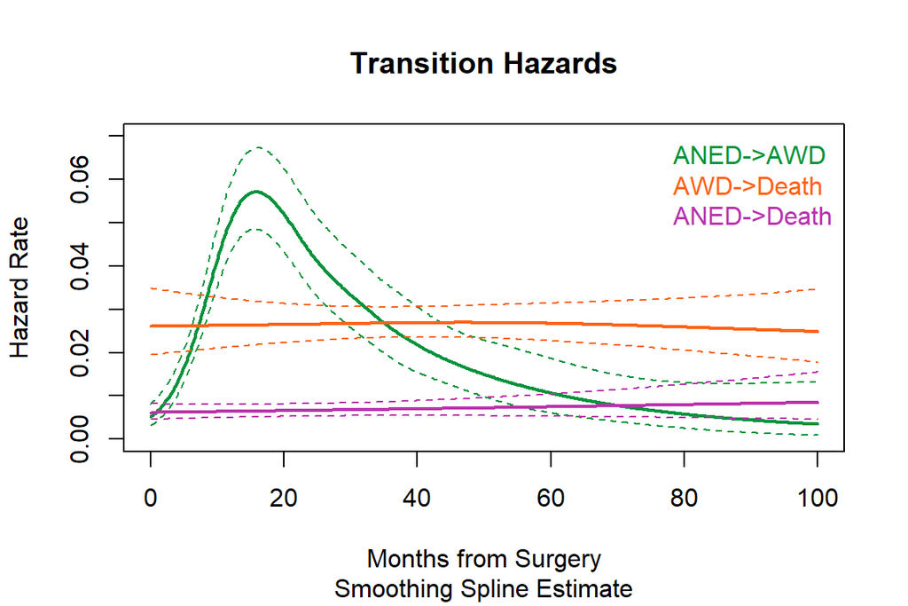

```r
matplot(tt,cbind(hA,hB,hC),type="l",
        ylim=c(0,.07),lty=c(1,2,2),
        lwd=c(2,1,1),col=c(1,1,1,2,2,2,3,3,3)+3,
        xlab="Months from Surgery",
        ylab="Hazard Rate",
        sub="Smoothing Spline Estimate",
        main="Transition Hazards")
legend("topright",text.col=4:6,
       legend=c("ANED->AWD","AWD->Death","ANED->Death"),bty="n")
```

# RNA covariates

Some processing for the RNA data file

```r
x<-read.table(
            file = "Data/data_mrna_seq_v2_rsem.txt",
            sep="\t",
            header=TRUE,
            colClasses = c("character",
                           "character",
                           rep("numeric",300)))
x<-x[x[,1]!="",]     # Drop missing HUGO
bar<-x[,1]

# Take sum over RSEM expected counts
# this just piles different gene concepts
# into the same bin
foo<-apply((x[,-(1:2)]),2,
           function(a)tapply(a,bar,sum))
colnames(foo)<-substr(gsub("\\.","-",colnames(foo)),1,12)

## We'll analyze on log
foo<-log(foo)        # some expected counts are <0
foo[is.nan(foo)]<-NA # kill them

sna<-apply(foo,1,var,na.rm=TRUE)
foo<-foo[sna>0,] # Genes have to have some variation

set<-intersect(rownames(dat1),colnames(foo))
dat<-dat1[set,]
rna<-foo[,set]

## drop any with no counts and any with more than 10% missing
rna<-rna[apply(is.na(rna),1,mean)<.1,]

## Subset to 1000 most variable for illustration
set<-names(rev(sort(apply(rna,1,var,na.rm=TRUE)))[1:1000])

dim(rna)
```

```
## [1] 17324   299
```

## OS and PFS with univariate PH effects

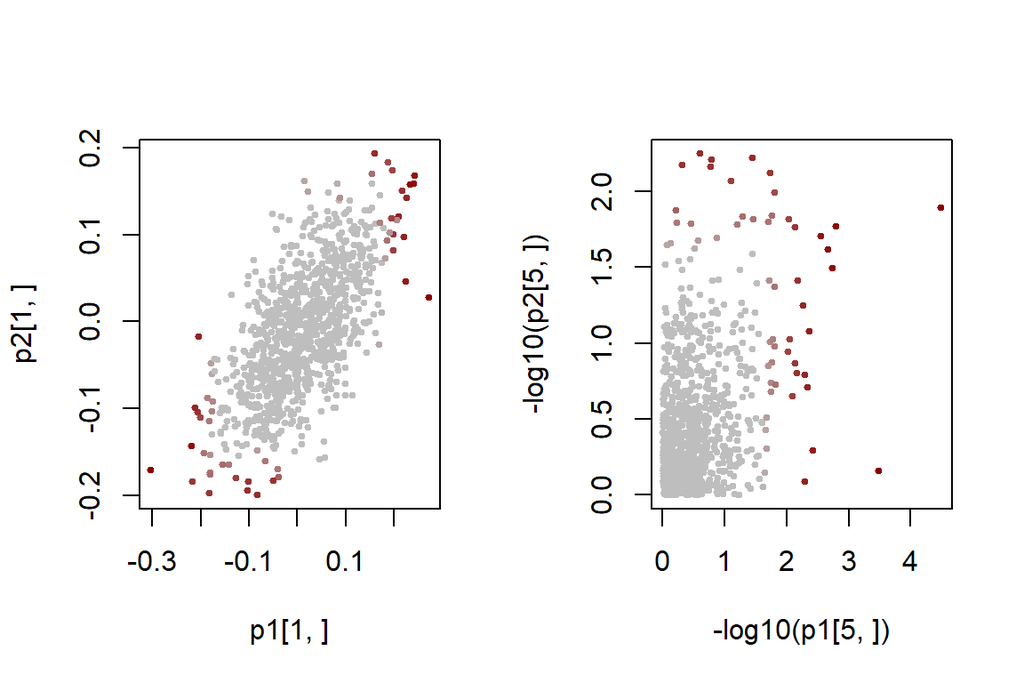

```r
data1<-dat1[colnames(rna),]

## Just do one per
p1<-apply(rna[set,],1,
          function(x)summary(coxph(Surv(time1,event1)~scale(x),data1))$coef[1,])
p2<-apply(rna[set,],1,
          function(x)summary(coxph(Surv(time2,event2)~scale(x),data1))$coef[1,])
p3<-1-(1-pmin(p1[5,],p2[5,]))^2
cc<-rev(colorRampPalette(c("grey","darkred"))(50))
c3<-as.numeric(cut(p3,breaks=c(seq(from=0,to=.05,length=50),1)))
c3<-cc[c3]

par(mfrow=c(1,2))
plot(p1[1,],p2[1,],col=c3,pch=19,cex=.5)
plot(-log10(p1[5,]),-log10(p2[5,]),col=c3,pch=19,cex=.5)
```

## OS and PFS with time-varying, non-PH effects

```r
## "ADAM6" has an okay pattern
## "AMPD1" simliar
gene<-rna["IGJ",]
df1<-data1;df1$time<-df1$time1;df1$x<-as.numeric(scale(gene))
ss1<-sshzd(Surv(time,event1)~time*x,
           data=df1,seed=609)
df2<-df1;df2$time<-df2$time2
ss2<-sshzd(Surv(time,event2)~time*x,
           data=df2,seed=609)
```

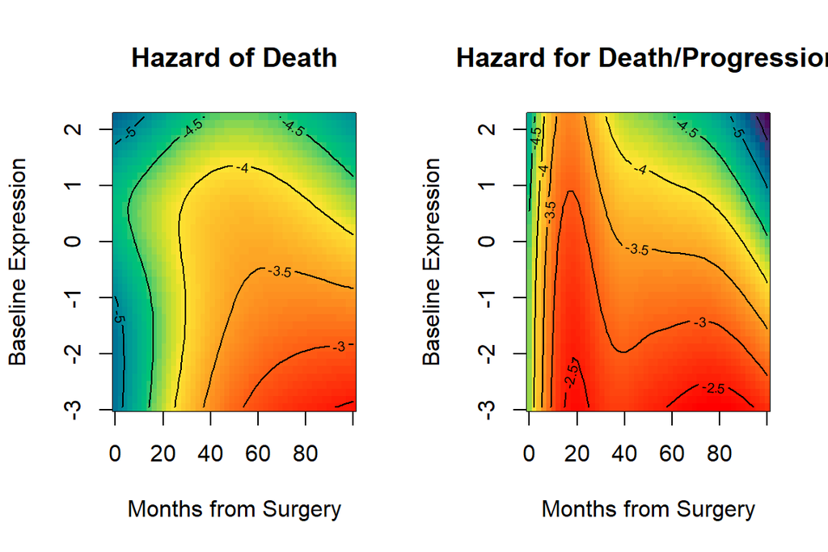

```r
## make 2 plots
nx<-40;nt<-50
ranx<-range(scale(gene),na.rm=TRUE)
grid.x<-seq(from=ranx[1],to=ranx[2],length=nx)
grid.t<-seq(from=0,to=100,length=nt)
xy<-expand.grid(time=grid.t,x=grid.x)

mm<-lapply(list(ss1,ss2),hzdrate.sshzd,x=xy)
mm<-lapply(mm,matrix,ncol=nx,nrow=nt)
mm<-lapply(mm,log)

lab<-c("Hazard of Death","Hazard for Death/Progression")
zlim<-range(unlist(mm),na.rm=TRUE)
col<-c(hcl.colors(50),colorRampPalette(c(hcl.colors(2)[2],"red"))(50))
par(mfrow=c(1,2))
for(k in 1:2){
  image(grid.t,grid.x,mm[[k]],main=lab[k],col=col,
        zlim=zlim,
        xlab="Months from Surgery",
        ylab="Baseline Expression")
  contour(grid.t,grid.x,mm[[k]],add=TRUE)
}
```

## multi-state with univariate effects

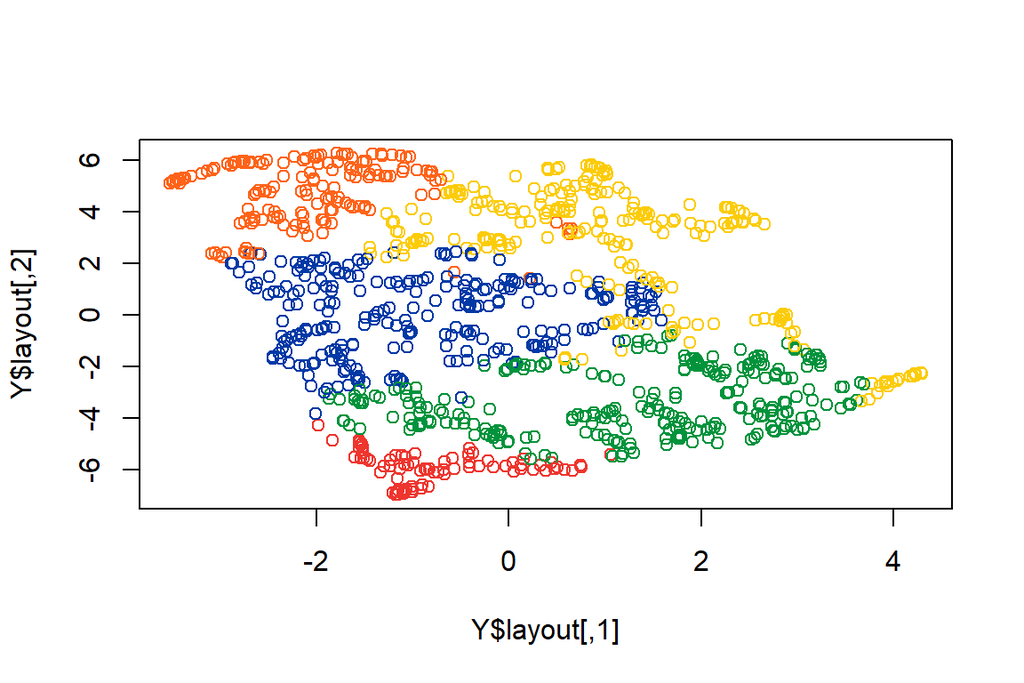

```r
mm<-match(dat3$id,colnames(rna))
pA<-apply(rna[set,mm],1,function(x){
   df<-na.omit(data.frame(dat3,x=scale(x)))
   ph<-coxph(Surv(tstart,tend,event=="prog")~x,
             data=df,subset=df$last=="(s0)")
   summary(ph)$coef[1,]
})
pB<-apply(rna[set,mm],1,function(x){
   df<-na.omit(data.frame(dat3,x=scale(x)))
   ph<-coxph(Surv(tstart,tend,event=="died")~x,
             data=df,subset=df$last=="prog")
   summary(ph)$coef[1,]
})
pC<-apply(rna[set,mm],1,function(x){
   df<-na.omit(data.frame(dat3,x=scale(x)))
   ph<-coxph(Surv(tstart,tend,event=="died")~x,
             data=df,subset=df$last=="(s0)")
   summary(ph)$coef[1,]
})

bb<-cbind(c(pA[1,]),c(pB[1,]),c(pC[1,]))

library(umap)
Y<-umap(bb)
km<-kmeans(bb,5)
plot(Y$layout,col=km$cluster)
```

```r
## Pick out an egregious one
#head(rev(sort((pA[1,]-pB[1,])^2)))
## C7orf52, ATP1A2, NAA11, KRT83, RD3, PRSS33
hit<-c("C7orf52","ATP1A2",             # pB specific
       "NAA11","KRT83","RD3","PRSS33") # pA specific
pA[c(1,5),hit]
```

```
##              C7orf52      ATP1A2       NAA11       KRT83         RD3     PRSS33
## coef     -0.06902905 -0.08061521 -0.15520220 -0.18837442 -0.16786880 -0.1518620
## Pr(>|z|)  0.35650274  0.31874720  0.07833283  0.01447683  0.03000819  0.0469001
```

```r
pB[c(1,5),hit]
```

```
##             C7orf52     ATP1A2     NAA11      KRT83       RD3    PRSS33
## coef     0.24444811 0.22098495 0.1381486 0.09869651 0.1129196 0.1154265
## Pr(>|z|) 0.01070381 0.01435945 0.1589236 0.24212123 0.2265676 0.2212000
```

## Time-varying, non-PH models

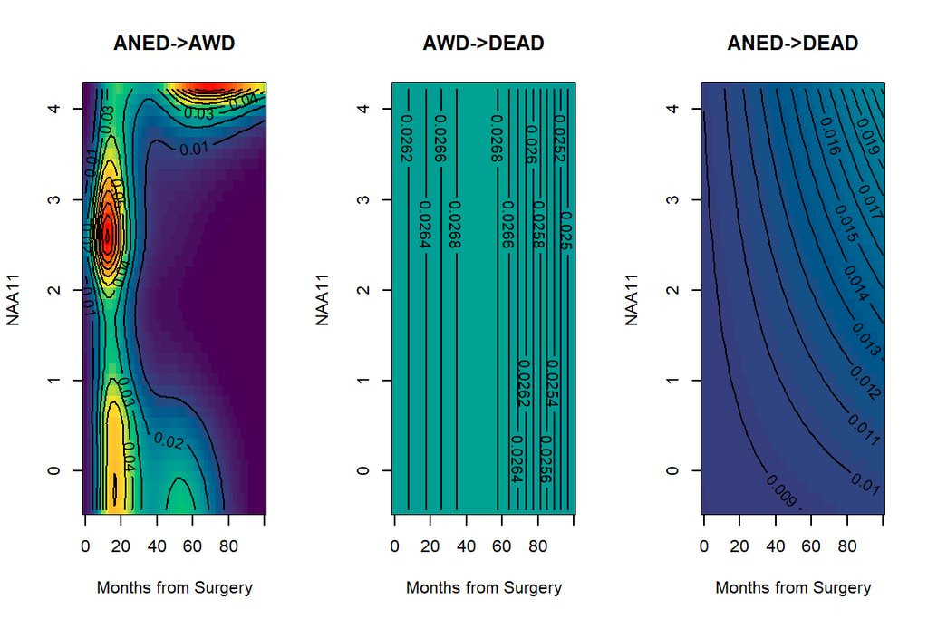

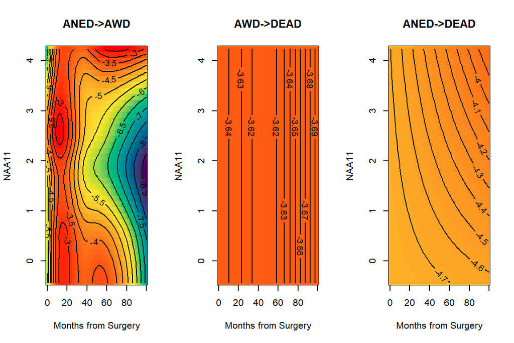

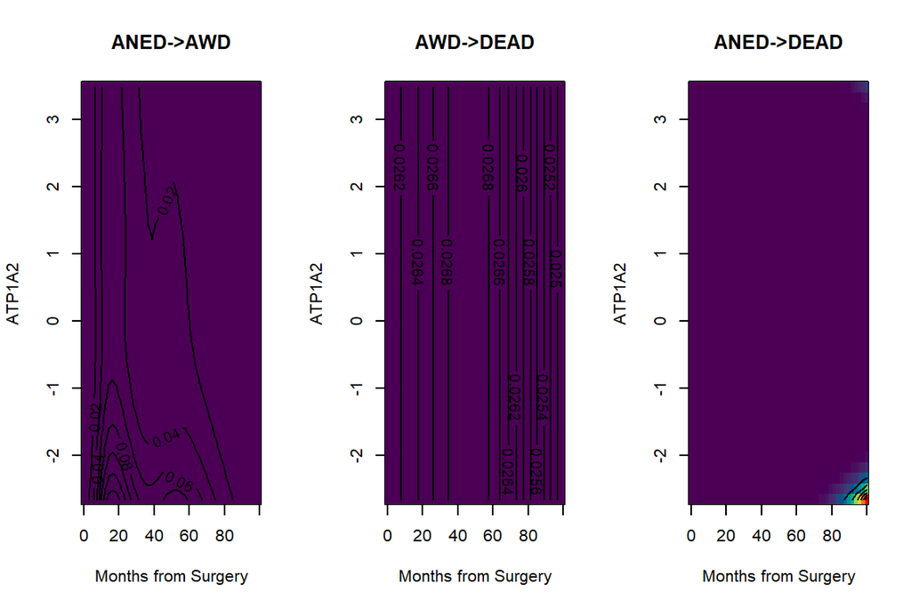

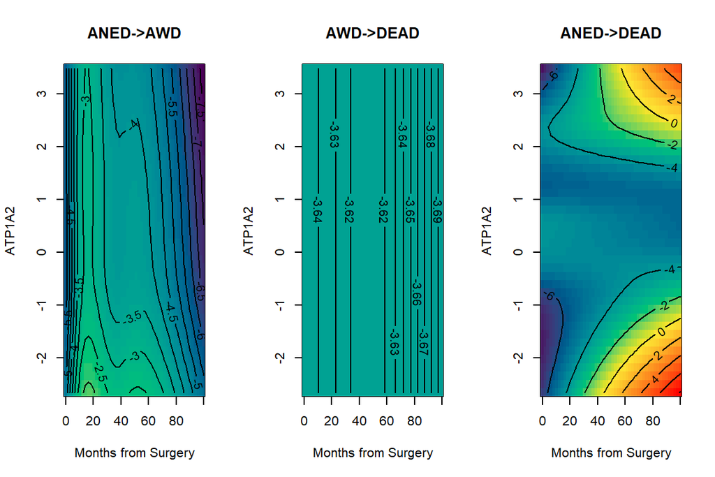

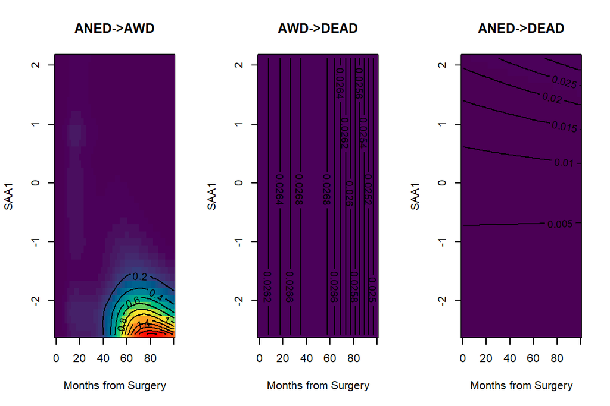

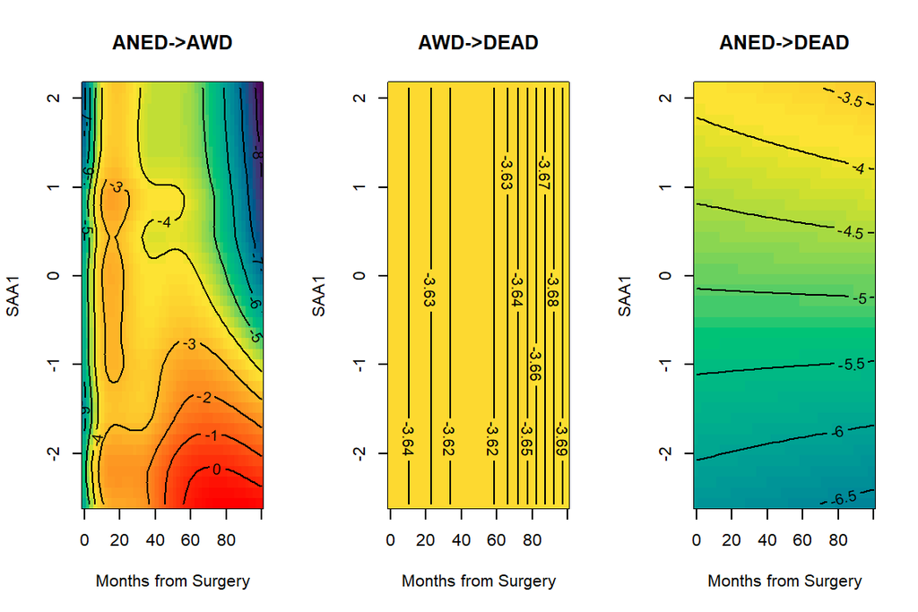

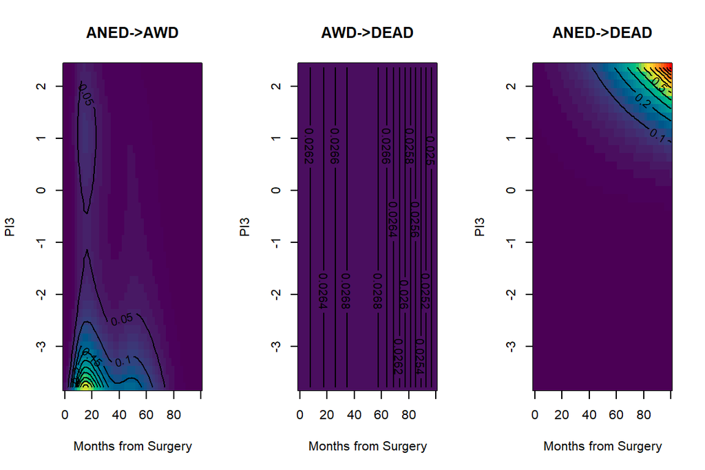

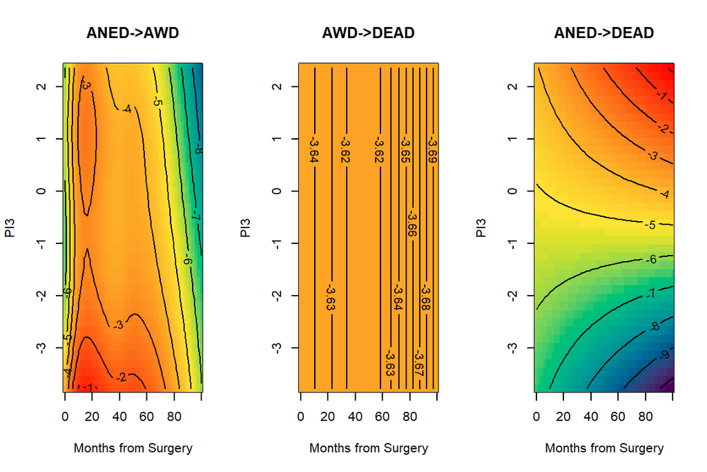

```r
## set up RNA alignment, I don't feel like copying
## a big rna data frame around, so I call it
## when I need it
mat<-match(dat3$id,colnames(rna))

## Pick NAA11; has interesting 1st plot
## Pick ATP1A2; has interesting last plot
## SAA1: Good baseline. Shows progression specific
## PI3, interesting first and last, but not enough gradient

hitlist<-c("NAA11","ATP1A2","SAA1","PI3")
lab<-c("ANED->AWD","AWD->DEAD","ANED->DEAD")
col<-c(hcl.colors(50),colorRampPalette(c(hcl.colors(2)[2],"red"))(50))


for(gen in hitlist){
  gene<-rna[gen,mat]
  df  <-na.omit(data.frame(dat3,x=scale(gene))) # much smaller

  ssA<-sshzd(Surv(tend,event=="prog", start=tstart)~tend*x,
             data=df,subset=df$last=="(s0)",
             seed=609)
  ssC<-sshzd(Surv(tend,event=="died", start=tstart)~tend*x,
             data=df,subset=df$last=="prog",
             seed=609)
  ssC<-sshzd(Surv(tend,event=="died", start=tstart)~tend*x,
             data=df,subset=df$last=="(s0)",
             seed=609)

  ## make 3 plots
  nx<-40;nt<-50
  ranx<-range(scale(gene),na.rm=TRUE)
  grid.x<-seq(from=ranx[1],to=ranx[2],length=nx)
  grid.t<-seq(from=0,to=100,length=nt)
  xy<-expand.grid(tend=grid.t,x=grid.x)

  mm<-lapply(list(ssA,ssB,ssC),hzdrate.sshzd,x=xy)
  mm<-lapply(mm,matrix,ncol=nx,nrow=nt)

  zlim<-range(unlist(mm),na.rm=TRUE)
  par(mfrow=c(1,3))
  for(k in 1:3){
    image(grid.t,grid.x,mm[[k]],main=lab[k],col=col,
          zlim=zlim,
          xlab="Months from Surgery",
          ylab=gen)
    contour(grid.t,grid.x,mm[[k]],add=TRUE)
  }

  mm<-lapply(mm,log)
  zlim<-range(unlist(mm),na.rm=TRUE)
  par(mfrow=c(1,3))
  for(k in 1:3){
    image(grid.t,grid.x,mm[[k]],main=lab[k],col=col,
          zlim=zlim,
          xlab="Months from Surgery",
          ylab=gen)
    contour(grid.t,grid.x,mm[[k]],add=TRUE)
  }
}
```